# L'elisir d'amore - Die Hamburgische Staatsoper

[Die Hamburgische Staatsoper](https://www.die-hamburgische-staatsoper.de/de)

[figure not shown]

Brinkhoff / Mögenburg

[Programm](https://www.die-hamburgische-staatsoper.de/de/programm/) → Oper

# L'elisir d'amore

Gaetano Donizetti

Inszenierung von 1977

- Sa 20.12. 19:00 Tickets
- Sa 27.12. 19:00 Tickets
- Fr 2.1. 19:00 Tickets
- Sa 10.1. 19:00 Tickets
- Zum letzten Mal in dieser Spielzeit

  So 25.1. 15:00 Tickets

Noch heute erzählt die 1977 entstandene Produktion des 1988 verstorbenen Regisseurs Jean Pierre Ponnelle fesselnd die Geschichte Nemorinos, der unglücklich in die Gutsbesitzerin Adina verliebt ist: Erst mit dem vermeintlichen Liebestrank eines ominösen Wunderdoktors nehmen die Gefühle ihren Lauf. Die Kräfte von Phantasie und Illusion, von Trug und Täuschung bringen Farbe in ein Dorf, vor dessen Toren der Krieg lauert.

## Ein Meilenstein der komischen Oper, der tief in das Seelenleben seiner Protagonisten blickt

Melodramma Giocoso in zwei Akten  
Komposition: Gaetano Donizetti  
Libretto: Felice Romani nach dem Libretto von August Eugène Scribe zu der Oper Le Philtre von Daniel Francois Esprit Auber (1831)

- 1832 12. Mai, Uraufführung am Teatro Lirico in Mailand
- 1977 18. Juni, Premiere dieser Inszenierung an der Hamburgischen Staatsoper
- 2026 Vor der letzten Vorstellung findet das Gespräch „Künstlerkopf im Fokus: Jean-Pierre Ponnelle“ zwischen Intendant Tobias Kratzer und Grischa Asagaroff statt. 25. Januar, 14:15 · Foyer 2. Rang

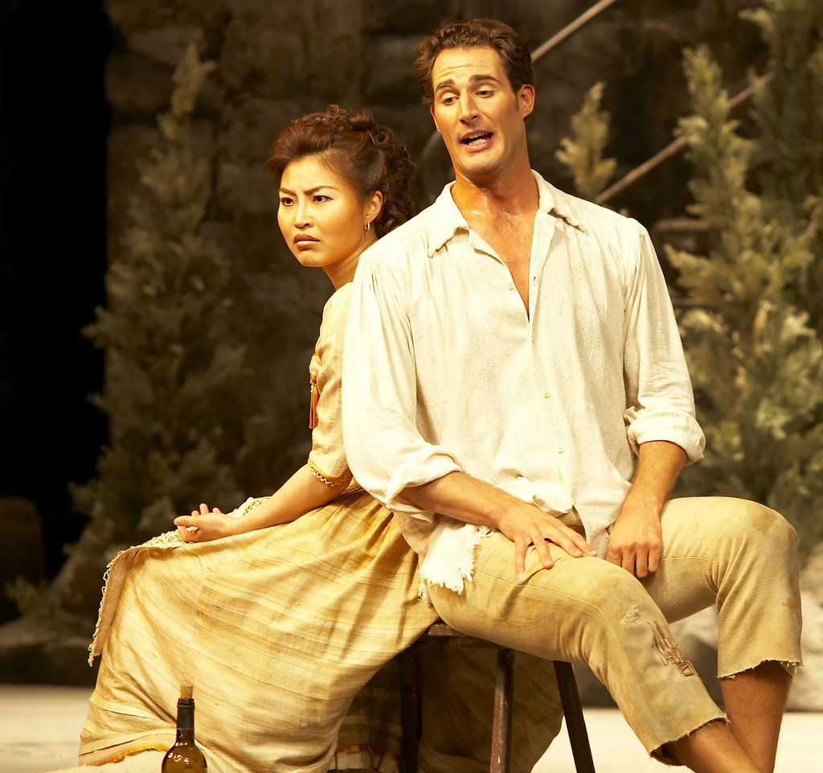

  2008 Brinkhoff/ Mögenburg

[figure not shown]

  2008 Brinkhoff/ Mögenburg

[figure not shown]

  2008 Brinkhoff/ Mögenburg

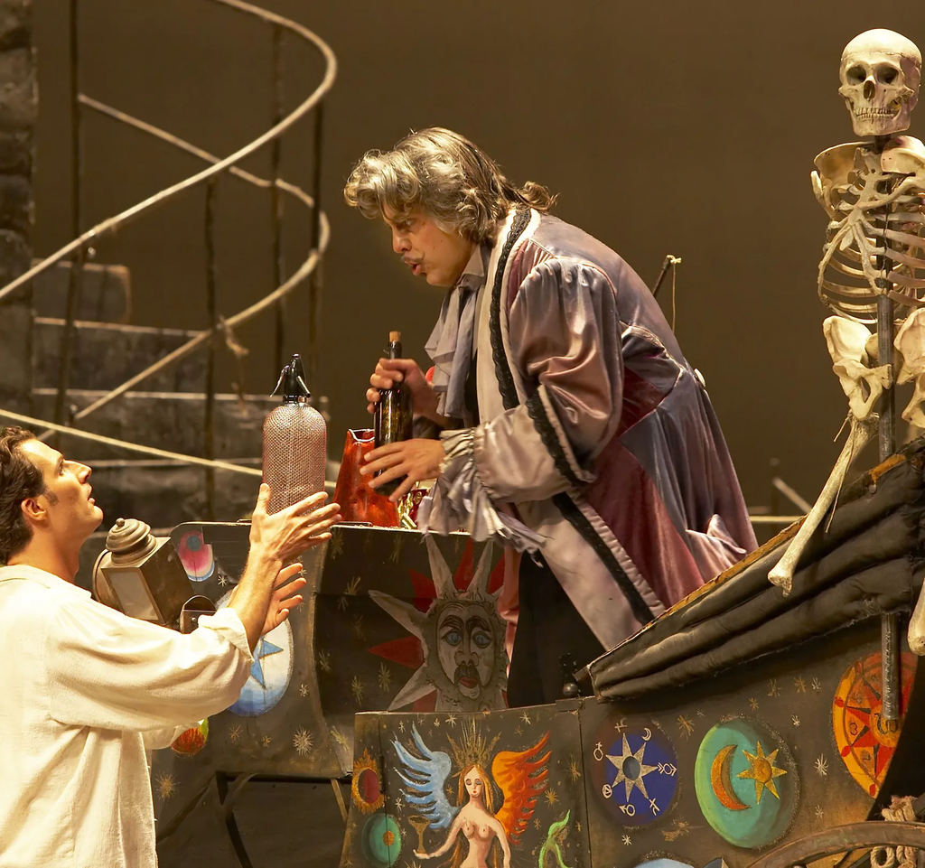

  2008 Brinkhoff/ Mögenburg

## Besetzung

- Musikalische Leitung

  [Omer Meir Wellber](https://www.die-hamburgische-staatsoper.de/de/personen/39915514-omer-meir-wellber)
  - 20.12.25 /
  - 27.12.25 /
  - 2.1.26 /

  [Keren Kagarlitsky](https://www.die-hamburgische-staatsoper.de/de/personen/39915822-keren-kagarlitsky)
  - 25.1.26
- Inszenierung und Bühne nach

  [Jean-Pierre Ponnelle †](https://www.die-hamburgische-staatsoper.de/de/personen/738-jean-pierre-ponnelle)
- Kostüme

  [Pet Halmen †](https://www.die-hamburgische-staatsoper.de/de/personen/739-pet-halmen)
- Chor

  [Alice Meregaglia](https://www.die-hamburgische-staatsoper.de/de/personen/39915784-alice-meregaglia)
- Adina

  [Nino Machaidze](https://www.die-hamburgische-staatsoper.de/de/personen/5437-nino-machaidze)
- Nemorino

  [René Barbera](https://www.die-hamburgische-staatsoper.de/de/personen/39914716-rene-barbera)
- Belcore

  [Nicholas Mogg](https://www.die-hamburgische-staatsoper.de/de/personen/39913011-nicholas-mogg)
- Dulcamara

  [Erwin Schrott](https://www.die-hamburgische-staatsoper.de/de/personen/2548-erwin-schrott)
- Giannetta

  [Mariana Poltorak](https://www.die-hamburgische-staatsoper.de/de/personen/2147496084-mariana-poltorak)
- [Chor der Hamburgischen Staatsoper](https://www.die-hamburgische-staatsoper.de/de/personen/5469-chor-der-hamburgischen-staatsoper)
- [Philharmonisches Staatsorchester Hamburg](https://www.die-hamburgische-staatsoper.de/de/personen/1929-philharmonisches-staatsorchester-hamburg)

## Das Stück

- Spielstätte Staatsoper, Großes Haus
- Dauer 150 Min
- Pause Eine Pause von ca. 30 Minuten nach dem ersten Akt (nach ca. 75 Minuten)
- Altersempfehlung Ab 12 Jahren / Klasse 7
- Sprache In italienischer Sprache mit deutschen und englischen Übertiteln

Seit fast 50 Jahren wird Donizettis Werk in der Regie des 1988 verstorbenen Regisseurs Jean Pierre Ponnelle am Haus gespielt. Eine liebevoll gearbeitete Inszenierung, der man gleichwohl ansieht, dass sie zu einer anderen Zeit entstanden ist. Die historische Dimension szenischer Interpretationen von Werken wird hier offenbar. Noch heute erzählt die Produktion fesselnd Nemorinos Geschichte, der unglücklich in die Gutsbesitzerin Adina verliebt ist. Erst als mit dem Auftreten des ominösen Wunderdoktors Dulcamara ein vermeintlicher Liebestrank zum Einsatz kommt, nehmen die Gefühle ihren Lauf. Die Kräfte von Phantasie und Illusion, von Trug und Täuschung bringen Farbe in ein Dorf, vor dessen Toren der Krieg lauert, die Manipulierbarkeit des Einzelnen und der Masse manifestieren sich.  
Uraufgeführt wurde das Melodramma giocoso am 12. Mai 1832 am Teatro Lirico in Mailand. Die Hamburger Inszenierung feierte am 18. Juni 1977 Premiere.

Rahmenprogramm

[figure not shown]

Mit FRAMING the REPERTOIRE beleuchten wir vergangene Inszenierungen als eigenständige Kunstform.

[Mehr dazu](https://www.die-hamburgische-staatsoper.de/de/ueberuns/oper/framing-the-repertoire)

- GUIDANCE: Diskutieren Sie mit jungen Expert:innen über Werk, Inszenierung und Relevanz – vor, während und nach jeder Vorstellung in den Foyers
- Vor der letzten Vorstellung findet das Gespräch „Künstlerkopf im Fokus: Jean-Pierre Ponnelle“ zwischen Intendant Tobias Kratzer und Grischa Asagaroff statt.  
  25. Januar, 14:15 · Foyer 2. Rang
- - Musikalische Leitung [Omer Meir Wellber](https://www.die-hamburgische-staatsoper.de/de/personen/39915514-omer-meir-wellber)

  Mit: [Nino Machaidze](https://www.die-hamburgische-staatsoper.de/de/personen/5437-nino-machaidze), [René Barbera](https://www.die-hamburgische-staatsoper.de/de/personen/39914716-rene-barbera), [Nicholas Mogg](https://www.die-hamburgische-staatsoper.de/de/personen/39913011-nicholas-mogg), [Erwin Schrott](https://www.die-hamburgische-staatsoper.de/de/personen/2548-erwin-schrott), [Mariana Poltorak](https://www.die-hamburgische-staatsoper.de/de/personen/2147496084-mariana-poltorak), [Chor der Hamburgischen Staatsoper](https://www.die-hamburgische-staatsoper.de/de/personen/5469-chor-der-hamburgischen-staatsoper), [Philharmonisches Staatsorchester Hamburg](https://www.die-hamburgische-staatsoper.de/de/personen/1929-philharmonisches-staatsorchester-hamburg)

  [Details](https://www.die-hamburgische-staatsoper.de/de/programm/oper/127-l-elisir-d-amore)
- - Musikalische Leitung [Omer Meir Wellber](https://www.die-hamburgische-staatsoper.de/de/personen/39915514-omer-meir-wellber)

  Mit: [Nino Machaidze](https://www.die-hamburgische-staatsoper.de/de/personen/5437-nino-machaidze), [René Barbera](https://www.die-hamburgische-staatsoper.de/de/personen/39914716-rene-barbera), [Nicholas Mogg](https://www.die-hamburgische-staatsoper.de/de/personen/39913011-nicholas-mogg), [Erwin Schrott](https://www.die-hamburgische-staatsoper.de/de/personen/2548-erwin-schrott), [Mariana Poltorak](https://www.die-hamburgische-staatsoper.de/de/personen/2147496084-mariana-poltorak), [Chor der Hamburgischen Staatsoper](https://www.die-hamburgische-staatsoper.de/de/personen/5469-chor-der-hamburgischen-staatsoper), [Philharmonisches Staatsorchester Hamburg](https://www.die-hamburgische-staatsoper.de/de/personen/1929-philharmonisches-staatsorchester-hamburg)

  [Details](https://www.die-hamburgische-staatsoper.de/de/programm/oper/127-l-elisir-d-amore)
- Zum drittletzten Mal in dieser Spielzeit
  - Musikalische Leitung [Omer Meir Wellber](https://www.die-hamburgische-staatsoper.de/de/personen/39915514-omer-meir-wellber)

  Mit: [Nino Machaidze](https://www.die-hamburgische-staatsoper.de/de/personen/5437-nino-machaidze), [René Barbera](https://www.die-hamburgische-staatsoper.de/de/personen/39914716-rene-barbera), [Nicholas Mogg](https://www.die-hamburgische-staatsoper.de/de/personen/39913011-nicholas-mogg), [Erwin Schrott](https://www.die-hamburgische-staatsoper.de/de/personen/2548-erwin-schrott), [Mariana Poltorak](https://www.die-hamburgische-staatsoper.de/de/personen/2147496084-mariana-poltorak), [Chor der Hamburgischen Staatsoper](https://www.die-hamburgische-staatsoper.de/de/personen/5469-chor-der-hamburgischen-staatsoper), [Philharmonisches Staatsorchester Hamburg](https://www.die-hamburgische-staatsoper.de/de/personen/1929-philharmonisches-staatsorchester-hamburg)

  [Details](https://www.die-hamburgische-staatsoper.de/de/programm/oper/127-l-elisir-d-amore)
- Zum vorletzten Mal in dieser Spielzeit
  - Musikalische Leitung [Omer Meir Wellber](https://www.die-hamburgische-staatsoper.de/de/personen/39915514-omer-meir-wellber)

  Mit: [Nino Machaidze](https://www.die-hamburgische-staatsoper.de/de/personen/5437-nino-machaidze), [René Barbera](https://www.die-hamburgische-staatsoper.de/de/personen/39914716-rene-barbera), [Nicholas Mogg](https://www.die-hamburgische-staatsoper.de/de/personen/39913011-nicholas-mogg), [Erwin Schrott](https://www.die-hamburgische-staatsoper.de/de/personen/2548-erwin-schrott), [Mariana Poltorak](https://www.die-hamburgische-staatsoper.de/de/personen/2147496084-mariana-poltorak), [Chor der Hamburgischen Staatsoper](https://www.die-hamburgische-staatsoper.de/de/personen/5469-chor-der-hamburgischen-staatsoper), [Philharmonisches Staatsorchester Hamburg](https://www.die-hamburgische-staatsoper.de/de/personen/1929-philharmonisches-staatsorchester-hamburg)

  [Details](https://www.die-hamburgische-staatsoper.de/de/programm/oper/127-l-elisir-d-amore)
- Zum letzten Mal in dieser Spielzeit
  - Musikalische Leitung [Keren Kagarlitsky](https://www.die-hamburgische-staatsoper.de/de/personen/39915822-keren-kagarlitsky)

  Mit: [Nino Machaidze](https://www.die-hamburgische-staatsoper.de/de/personen/5437-nino-machaidze), [René Barbera](https://www.die-hamburgische-staatsoper.de/de/personen/39914716-rene-barbera), [Nicholas Mogg](https://www.die-hamburgische-staatsoper.de/de/personen/39913011-nicholas-mogg), [Erwin Schrott](https://www.die-hamburgische-staatsoper.de/de/personen/2548-erwin-schrott), [Mariana Poltorak](https://www.die-hamburgische-staatsoper.de/de/personen/2147496084-mariana-poltorak), [Chor der Hamburgischen Staatsoper](https://www.die-hamburgische-staatsoper.de/de/personen/5469-chor-der-hamburgischen-staatsoper), [Philharmonisches Staatsorchester Hamburg](https://www.die-hamburgische-staatsoper.de/de/personen/1929-philharmonisches-staatsorchester-hamburg)

  [Details](https://www.die-hamburgische-staatsoper.de/de/programm/oper/127-l-elisir-d-amore)

[interactive chart not shown]